## Endangered Species of the Felidae Family

By: Eunice Choi & Melissa Barcelona

#### The breakdown:

1. Curl the felidae page from www.iucnredlist.org
2. Webscrape general information (species name, threat level, population trend)
3. R Studio to create bar graphs to compare threat levels and population trends.
4. Curl link for each species
5. Webscrape geographic locations
6. R Studio to create stacked bar graphs to compare number of species by threat level in each continent
7. R Studio to create and analyze maps with species locations and an urbanization layer

### 1. Curl and Webscrape Felidae Database

```python
curl 'http://www.iucnredlist.org/search' -H 'Host: www.iucnredlist.org' -H 'User-Agent: Mozilla/5.0 (Macintosh; Intel Mac OS X 10.10; rv:35.0) Gecko/20100101 Firefox/35.0' -H 'Accept: text/html,application/xhtml+xml,application/xml;q=0.9,*/*;q=0.8' -H 'Accept-Language: en-US,en;q=0.5' --compressed -H 'Referer: http://www.iucnredlist.org/' -H 'Cookie: _newiucnredlist_session=2f736adea4e261166188977cec387f23; __utma=107924634.1582988870.1424392749.1424392749.1424392749.1; __utmb=107924634.2.10.1424392749; __utmc=107924634; __utmz=107924634.1424392749.1.1.utmcsr=iucn.org|utmccn=(referral)|utmcmd=referral|utmcct=/knowledge/tools/databases/; __utmt=1' -H 'Connection: keep-alive' -H 'If-None-Match: "34c4a2eb0a0d43839b67ba3d5c22f1a7"' -H 'Cache-Control: max-age=0' > felidae_web.html
#curl website and save data onto file

from bs4 import BeautifulSoup
soup = BeautifulSoup(open("felidae_web.html"))
#open a new file to write onto
file= open("felidae_data.html", "w", "r")
#find description of species
felidae_pane=soup.find(id="results")
felidae_li= felidae_pane.find_all("li")
for li in felidae_li:
  status= li.find(class_="desc")
  for string in status.strings:
    #write webscraped data onto the new file
    file.write(string.strip())
```

### 2. Extract Population Trend Data

```python
#open new file called poptrend
file = open("poptrend.txt","w",)
#Search for population trends in felidae file
for line in open('felidae_web'):
    rec = line.strip()
    if rec.startswith('Pop'):
        #write lines population trends onto the new file
        file.write(line)
        file.close()

#open poptrend file
file = open(r"poptrend.txt", "r", encoding="utf-8-sig")
from collections import Counter
#count number of each trend
wordcount = Counter(file.read().split())
#print population trend next to count
for item in wordcount.items(): print({}\t{}".format(*item))
```

Now we will open a new file called “poptrend.txt” and extract just the population trends from the file that we created in the earlier step. We write a for loop that searches through “felidae_web.html” and writes down lines that start with ‘Pop’ onto “poptrend.txt”. Then we close the new file. Now we have a text file that has just the population trends of the species! Next we open poptrend.txt and count the number of each word in order to get the frequency of “decreasing”, “stable”, and “unknown”. This tells us the number of different population trends. We will use this data to create a bar graph.

### 3. Population Trend Analysis

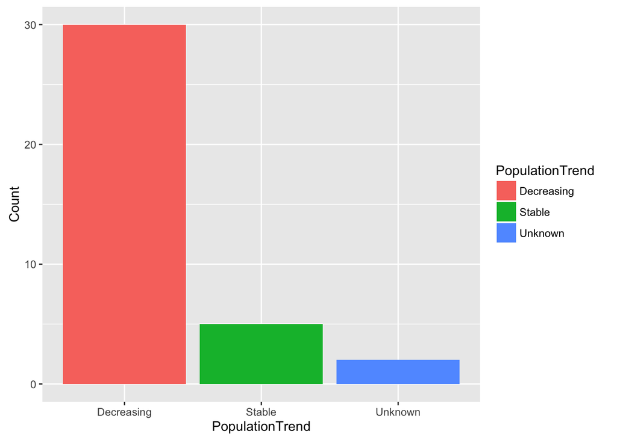

```r
#define read.table for population trend count
df <- read.table(text='Count    PopulationTrend
2  Unknown
5 Stable
30  Decreasing', header=TRUE)

library("ggplot2")
#plot population trend onto a bar graph
ggplot(data=df, aes(x=PopulationTrend, y=Count)) +
  geom_bar(aes(fill=PopulationTrend), stat="identity")
```

In order to create a bar graph, we use the population trend data obtained in the step before and create a table in RStudio. Then we define read.table as “df” so that ggplot can use df as the data source for creating a bar graph. We set the variables for our graph, and voila! we have a simple visualization for the population trends.

### 4. Extract Threat Level Data

```
#open new file called threatlevel
file = open("threatlevel.txt","w",)
#Search for threatlevels in felidae file
for line in open('felidae_web'):
    rec = line.strip()
    if rec.startswith('Status'):
        #write lines population trends onto the new file
        file.write(line)
        file.close()

#open threatlevel file
file = open(r"threatlevel.txt", "r", encoding="utf-8-sig")
from collections import Counter
#count number of each threat level
wordcount = Counter(file.read().split())
#print threat level next to count
for item in wordcount.items(): print({}\t{}".format(*item))
```

Next we want to extract the threat level data. We do the exact same thing we did to get the population trends, with the only difference of writing lines that start with ‘Status’ instead of ‘Pop’ onto a new file called threatlevel.txt. Then we count the number of words to get the frequency of “LeastConcerned”, “NearThreatened”, “Vulnerable”, “Endangered”, and “CriticallyEndangered”.

### 5. Threat Level Analysis

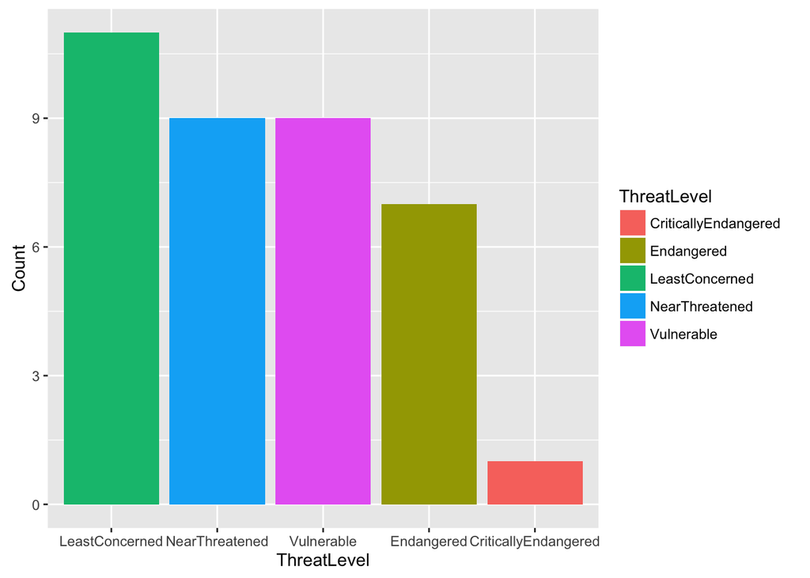

```r
#define read.table for threatlevel count
df <- read.table(text='Count    ThreatLevel
9  Vulnerable
7 Endangered
1 CriticallyEndangered
9 NearThreatened
11  LeastConcerned', header=TRUE)

library("ggplot2")
#order x axis values
ThreatLevel <- c("LeastConcerned", "NearThreatened", "Vulnerable", "Endangered", "CriticallyEndangered")
#plot threatlevel trend onto bar graph
ggplot(data=df, aes(x = ThreatLevel, y=Count)) +
  scale_x_discrete(limits = ThreatLevel) +
  geom_bar(aes(fill=ThreatLevel), stat="identity")
```

Again, we do the same thing we did with the population trends and create a bar graph in RStudio that compares the count of different threat levels of the species. Before we ggplotted the data, we ordered the x-axis values so that the threatlevels are labeled from least to most threatened on the x-axis.

## Moving on..

With our population trend and threat level analysis done, we want to further analyze the geographic locations of these felidae species. However, this information is not on the main felidae page that we initially webscraped. To get this information, we need to click on a species link which will then list its geographic locations by country. Since it would be too tedious to go through each link and copy the geographic locations, we can instead create a list of websites for each species from felidae_web.html, curl each site, and then webscrape the geographic locations for each species all at once!

[output not shown]

### 6. Curling Species’ Websites

```python
#open file with all links
file = open("felidae_links.txt").readlines()
import subprocess
import sys
#count
count = 0
#write loop that curls each link into files with numerical labels
for line in file:
        count+=1
        print "links{}.html".format(count), line
        subprocess.call(['curl','-L',' -o',"links{}.html".format(count),line.strip()])
```

Here we wrote a python script to curl through the websites in felidae_links.txt. We open our file and import subprocess and sys. We need to save the curled websites onto new individual files, so we use count to count up and create a numbered link for each of the curled files to be saved onto. These files are all saved into one directory. Now we can go through each of the curled links to find the data we are looking for: the geographic locations of each species.

### 7. Finding geographic locations

```python
import glob
import re
import codecs
#import program
all_html = glob.glob("links*.html") #glob links
file= codecs.open("felidae_geog.txt", "w", "utf-8")
for html_file in all_html: #loop through html file
    with open(html_file, "r") as rfile:
        #find scientific name and countries
        soup = BeautifulSoup(rfile)
        name = soup.find('span', {'class': 'sciname'}).text
        georange = soup.find('div', {'class': 'group'}).text
        print (name) + (georange) + '\n' + '\n'
        #write data to a file
        file.write((name)+(georange) + '\n' + '\n')
```

Here we have a code that goes through the curled links of each species and finds the information we are looking for. We import glob and re to go through each felidae link in our link directory. We create a new file, felidae_geog.txt, which will hold all the information for the geographic locations of each species. We find the text we are looking for under the class “sciname” and “group”, which gives us the scienctific name and respective countries. We save this onto felidae_geog.txt. Now we can begin creating a stacked bar graph that shows the proportion of each species by threat levels in each continent.

### 8. Threat Level Analysis by Continent

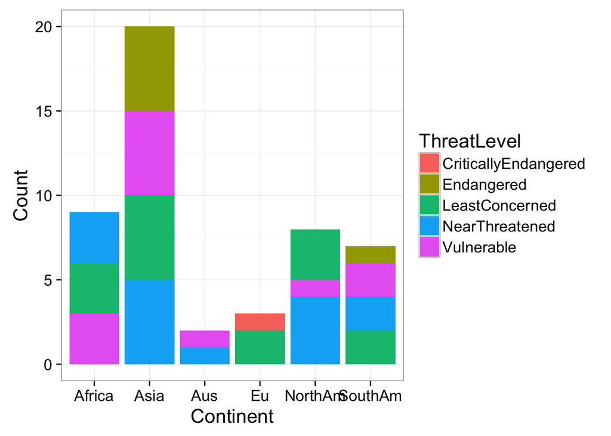

```r
#read table with species separated by threat and continent
df <- read.table(text='Count    ThreatLevel  Continent
                4  NearThreatened  NorthAm
1 Vulnerable  NorthAm
3 LeastConcerned  NorthAm
2 LeastConcerned  SouthAm
2 NearThreatened  SouthAm
2 Vulnerable  SouthAm
1 Endangered  SouthAm
2 LeastConcerned  Eu
1 CriticallyEndangered  Eu
5 NearThreatened  Asia
5 LeastConcerned  Asia
5 Vulnerable  Asia
5 Endangered  Asia
3 Vulnerable  Africa
3 LeastConcerned  Africa
3 NearThreatened  Africa
1 NearThreatened  Aus
1 Vulnerable  Aus', header=TRUE)

#plot using ggplot
require(ggplot2)
p <- ggplot(df, aes(Continent, Count, fill=ThreatLevel)) +
    geom_bar(stat='identity') +
    theme_bw(base_size=16)
print(p)
```

### 9. Getting latitude and longitude

```r
#load packages
library("ggmap")

#concatenate list of countries for each species
Leopardus_tigrinus <- c("Argentina", "Bolivia,
Plurinational States of", " Brazil",
"Colombia", "Costa Rica", "Ecuador",
"French Guiana", "Guyana", " Panama",
"Paraguay", "Peru", "Suriname", "Venezuela")

#geocode countries and save as a table
ll.Leopardus_tigrinus = geocode(Leopardus_tigrinus)
```

We decide to use R to map the geographic locations of our felidae species, but first, we need to find the latitude and longitude of the countries we found. An example is shown above using leopardus tigrinus. We first load the package ggmap. We then create a list in R containing the list of countries. Then we use the function “geocode” that allows us to send this list into google maps and returns the latitude and longitude for each country in the list as a table. We define the table as ll.Leopardus_tigrinus (for latitude and longitude). This was done for all 37 species. With our locations ready, we can begin setting up our maps.

To map our data, we chose to use shapefiles from NaturalEarth. These shapefiles create our map by adding the layers we want on it. This includes the continents, countries, bounding box, sites of urbanization, and gridlines.

### 10. Getting our shapefiles ready

```r
#load packages
library(rgdal)
library(ggplot2)
library(sp)

# read world map shapefile from NaturalEarth
worldmap = readOGR(dsn="ne_110m_land.shp", layer="ne_110m_land")
# convert to dataframe
worldmap_df = fortify(worldmap)

# read graticule shapefile
grat = readOGR("ne_110m_graticules_15.shp", layer="ne_110m_graticules_15")
grat_df = fortify(grat)

# read bounding box shapefile
bbox = readOGR("ne_110m_wgs84_bounding_box.shp", layer="ne_110m_wgs84_bounding_box")
bbox_df = fortify(bbox)

# read urban areas shapefile
urban = readOGR("ne_50m_urban_areas.shp", layer="ne_50m_urban_areas")
urban_df = fortify(urban)

#read countries shapefile
countries=readOGR("ne_110m_admin_0_countries.shp", layer ="ne_110m_admin_0_countries")
countries_df = fortify(countries)

#convert all to dataframe
```

First we load the packages rgdal, ggplot2, and sp. We open each shapefile and fortify them so they can be used as a dataframe. Now we can put everything together in a map!

### 12. Putting it all together!

```r
library(ggplot2)
ggplot(bbox_df, aes(x=long,y=lat, group=group)) + #plot map
  geom_polygon(fill="#58D3F7") +
  geom_polygon(data=worldmap_df, aes(x=long,y=lat, group=group, fill=hole)) + #add world map
  geom_path(data=countries_df, aes(x=long,y=lat, group=group, fill=hole), color="#0B610B") +
  #add countries
  geom_polygon(data=urban_df, aes(x=long,y=lat, group=group, fill=hole), color="#BDBDBD", border="#848484", lwd=0.2, add=TRUE,
  alpha = 0.1) + #add urban areas
  geom_point(data=ll.Lynx_pardinus, aes(x=lon,y=lat, group=NULL), color="#FE2E9A", lwd=5.0,alpha = 0.7) + #add species points
  labs(title="Critically Endangered Felidae Species") + #add labels
  coord_equal() + #add coordinates
  scale_fill_manual(values=c("#04B404", "#58D3F7"), guide="none")
  #color land
```

Here we use ggplot to create our map. We create our map by first mapping the bounding box, then the world map, coutries layer, sites of dense urbanization (we color this grey), and then finally the data points of each species. We added in some aesthetics, including coloring the land green and the ocean blue, and making the plot points transparent. In the example above, only one species’ respective countries are plotted. However, for our final maps, we plotted multiple species onto a map based on their threat level (Least Concern, Near Threatened, Vulnerable, Endangered, and Critically Endangered). Each species is a different shade of a color to distinguish themselves amongst the others. The points are also transparent so they can be seen over the urbanization layer.

With these maps, we can analyze whether the threat level of these species are related to their proximity to dense sites of urbanization!

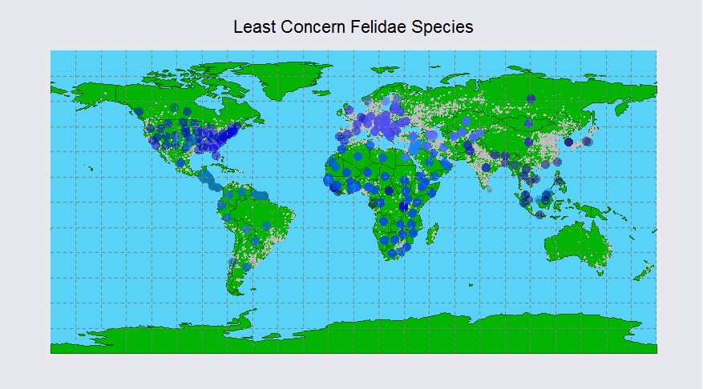

Map of Least Concern Species

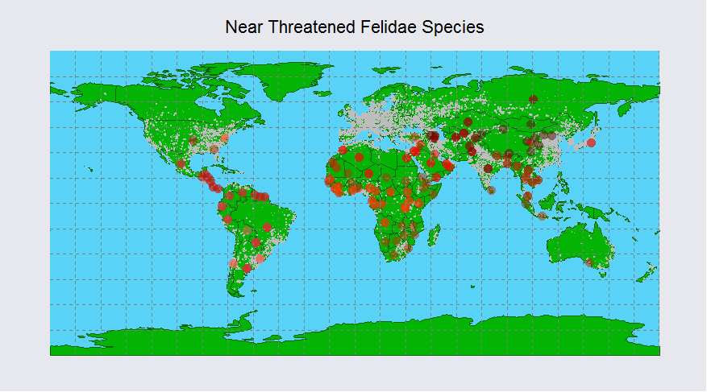

Map of Near Threatened Species

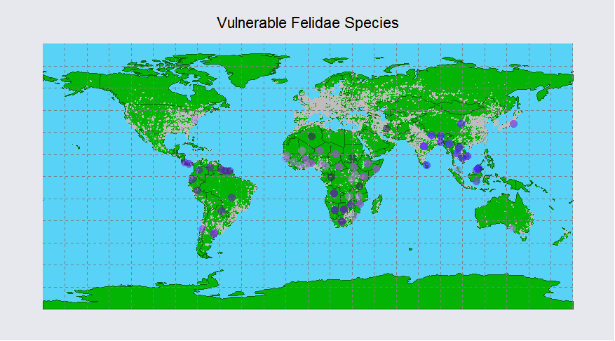

Map of Vulnerable Species

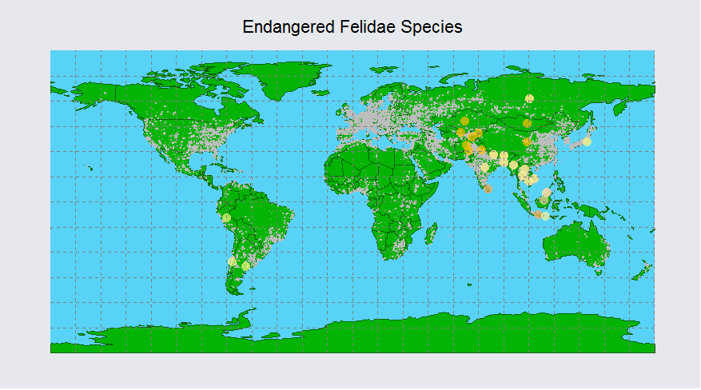

Map of Endangered Species

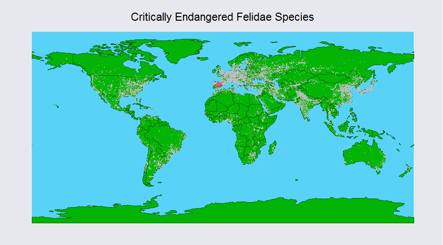

Map of Critically Endangered Species

### Now what?

This study can be applied in many different ways. Since only urbanization didn’t seem to directly correlate with endangerment, there must be other factors involved, such as global warming and climate change. Some future work can include adding different layers to the map and looking for other correlations.

## The End

Thank you